# Sample Analysis

Author

Prabin Roka

# Introduction

### Decoding Tipping Patterns

Tipping is a complex social and economic behavior influenced by a variety of factors, including service quality, cultural norms, and customer demographics. While tipping is often seen as a simple gesture of appreciation, it reflects deeper patterns that can be analyzed and predicted using data-driven approaches. This project leverages the **TIPS dataset**, which records tipping behavior in a restaurant setting, to explore the factors influencing tipping and build predictive models for tip amounts and percentages. By combining exploratory data analysis with machine learning techniques, we aim to uncover actionable insights that can benefit restaurant owners, service staff, and customers alike.

Our goal is to answer the following questions:

1. **Which factors have the strongest influence on tipping behavior?**

   After feature selection, `Bill` and `PartySize` demonstrated the strongest numerical correlations with `TipPercentage` and `TipCategory`. However, the models’ limitations indicate that unobserved factors, like service quality and customer satisfaction, likely play a significant role.
2. **How accurately can we predict tip amounts and percentages? What machine learning models perform best in predicting tipping behavior, and how reliable are their predictions?**

   With initial modeling, accuracy was poor. However, after applying correlation-based feature selection, the Ridge regression model significantly improved in predicting `TipPercentage` (RMSE: 1.76, R-squared: 0.876), and the KNN model substantially improved in predicting `TipCategory` (Accuracy: 0.865).

   After feature selection, the Ridge regression model performed slightly better than the linear regression model for predicting `TipPercentage`, and the KNN model performed well for predicting `TipCategory`. While feature selection greatly improved reliability, further research with more data and models may be needed to achieve higher accuracy.
3. **What actionable insights can restaurants derive from this analysis?**

   Restaurants should cautiously consider the relationships between `Bill`, `PartySize`, and `Time` with tipping patterns, but recognize the importance of unobserved factors. Focusing on enhancing service quality, gathering customer feedback, and exploring additional relevant variables could improve customer satisfaction and revenue.

By analyzing this dataset, we aim to uncover patterns and relationships that can help us better understand tipping behavior and provide actionable insights for the restaurant industry.

## Understanding the data

Today we will be working with the `TIPS` data set which is in the `regclass` package. The data in the `TIPS` dataset is information recorded by one waiter about each tip he received over a period of a few months working in a restaurant.

### Exercise 1: Setting up the Analysis Environment

In this initial exercise, we aim to establish the necessary environment for our data analysis. This involves loading the required R libraries and importing the TIPS dataset. We will then examine the data’s basic structure and summary statistics to gain an initial understanding of its contents.

```r
library(tidyverse)
library(caret)
library(workflows)
library(tidymodels)
library(knitr)
library(regclass)
data("TIPS")
head(TIPS)
```

```
  TipPercentage  Bill  Tip Gender Smoker Weekday  Time PartySize
1          5.94 16.99 1.01 Female     No  Sunday Night         2
2         16.10 10.34 1.66   Male     No  Sunday Night         3
3         16.70 21.01 3.50   Male     No  Sunday Night         3
4         14.00 23.68 3.31   Male     No  Sunday Night         2
5         14.70 24.59 3.61 Female     No  Sunday Night         4
6         18.60 25.29 4.71   Male     No  Sunday Night         4
```

```r
str(TIPS)
```

```
'data.frame':   244 obs. of  8 variables:
 $ TipPercentage: num  5.94 16.1 16.7 14 14.7 18.6 22.8 11.6 13 21.9 ...
 $ Bill         : num  17 10.3 21 23.7 24.6 ...
 $ Tip          : num  1.01 1.66 3.5 3.31 3.61 4.71 2 3.12 1.96 3.23 ...
 $ Gender       : Factor w/ 2 levels "Female","Male": 1 2 2 2 1 2 2 2 2 2 ...
 $ Smoker       : Factor w/ 2 levels "No","Yes": 1 1 1 1 1 1 1 1 1 1 ...
 $ Weekday      : Factor w/ 4 levels "Friday","Saturday",..: 3 3 3 3 3 3 3 3 3 3 ...
 $ Time         : Factor w/ 2 levels "Day","Night": 2 2 2 2 2 2 2 2 2 2 ...
 $ PartySize    : int  2 3 3 2 4 4 2 4 2 2 ...
```

```r
summary(TIPS)
```

```
 TipPercentage        Bill            Tip            Gender    Smoker
 Min.   : 3.56   Min.   : 3.07   Min.   : 1.000   Female: 87   No :151
 1st Qu.:12.88   1st Qu.:13.35   1st Qu.: 2.000   Male  :157   Yes: 93
 Median :15.45   Median :17.80   Median : 2.900
 Mean   :16.08   Mean   :19.79   Mean   : 2.998
 3rd Qu.:19.12   3rd Qu.:24.13   3rd Qu.: 3.562
 Max.   :71.00   Max.   :50.81   Max.   :10.000
     Weekday      Time       PartySize
 Friday  :19   Day  : 68   Min.   :1.00
 Saturday:87   Night:176   1st Qu.:2.00
 Sunday  :76               Median :2.00
 Thursday:62               Mean   :2.57
                           3rd Qu.:3.00
                           Max.   :6.00
```

**Observations:**

- The dataset contains 244 observations and 8 variables.
- Variables include Bill, Tip, TipPercentage, Gender, Smoker, Weekday, Time, and PartySize.
- Categorical variables like Gender, Smoker, Weekday, and Time are stored as factors.
- Numerical variables show variability and potential skewness.

### Exercise 2: **Visualizing Distributions**

This exercise focuses on visualizing the distributions of both numerical and categorical variables within the TIPS dataset. We aim to identify any skewness, outliers, or unusual patterns that might influence our subsequent analysis and modeling.

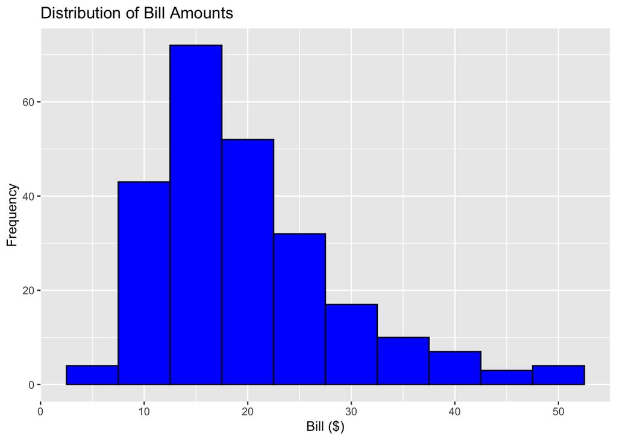

```r
library(ggplot2)

# Histogram for Bill
ggplot(TIPS, aes(x = Bill)) +
  geom_histogram(binwidth = 5, fill = "blue", color = "black") +
  labs(title = "Distribution of Bill Amounts", x = "Bill ($)", y = "Frequency")
```

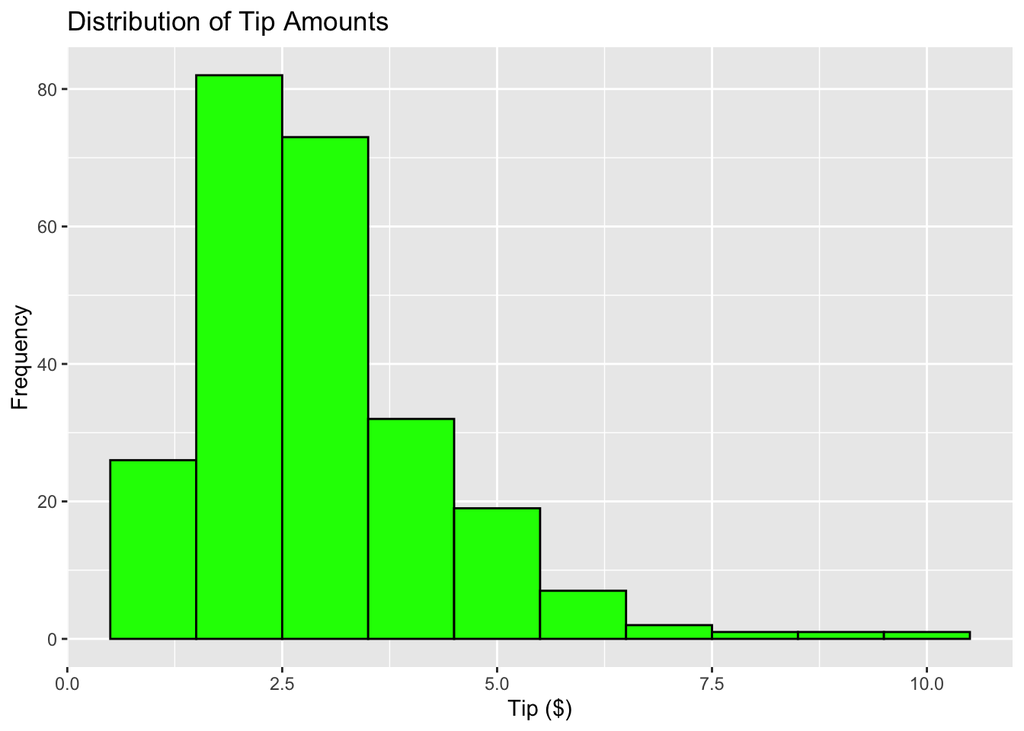

```r
# Histogram for Tip
ggplot(TIPS, aes(x = Tip)) +
  geom_histogram(binwidth = 1, fill = "green", color = "black") +
  labs(title = "Distribution of Tip Amounts", x = "Tip ($)", y = "Frequency")
```

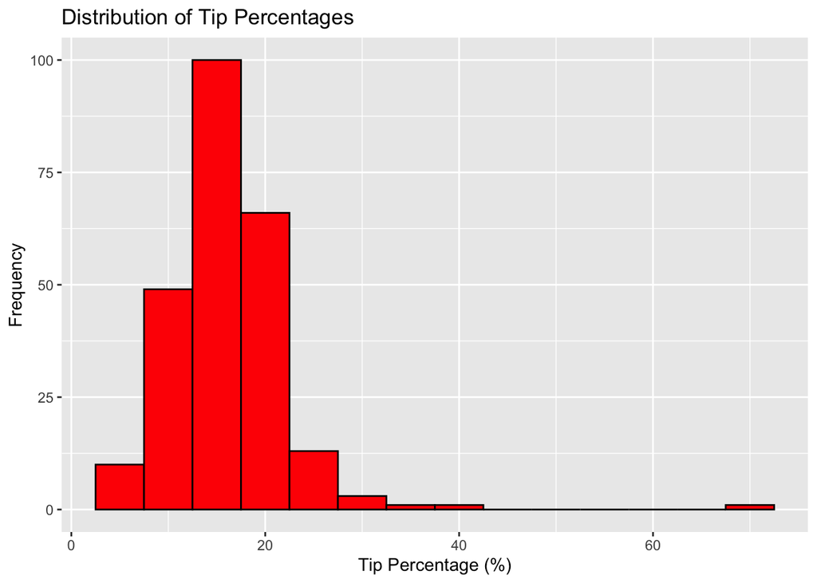

```r
# Histogram for TipPercentage
ggplot(TIPS, aes(x = TipPercentage)) +
  geom_histogram(binwidth = 5, fill = "red", color = "black") +
  labs(title = "Distribution of Tip Percentages", x = "Tip Percentage (%)", y = "Frequency")
```

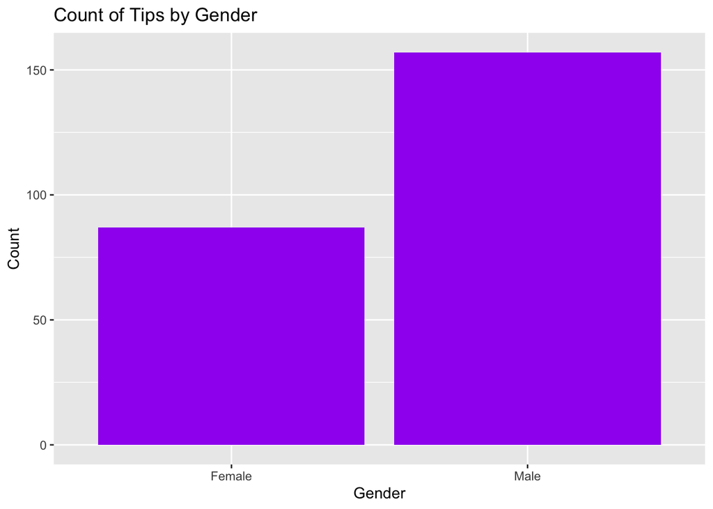

```r
# Bar plot for Gender
ggplot(TIPS, aes(x = Gender)) +
  geom_bar(fill = "purple") +
  labs(title = "Count of Tips by Gender", x = "Gender", y = "Count")
```

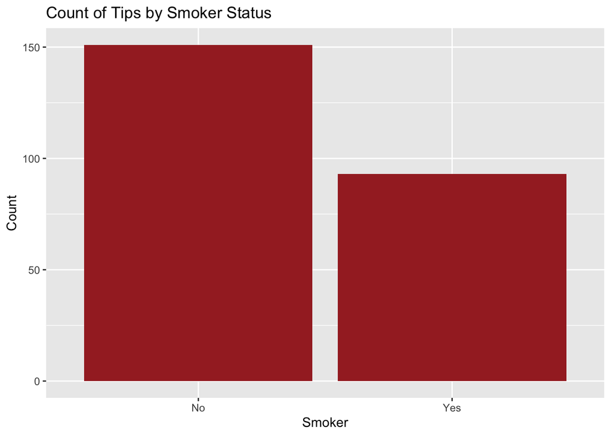

```r
# Bar plot for Smoker
ggplot(TIPS, aes(x = Smoker)) +
  geom_bar(fill = "brown") +
  labs(title = "Count of Tips by Smoker Status", x = "Smoker", y = "Count")
```

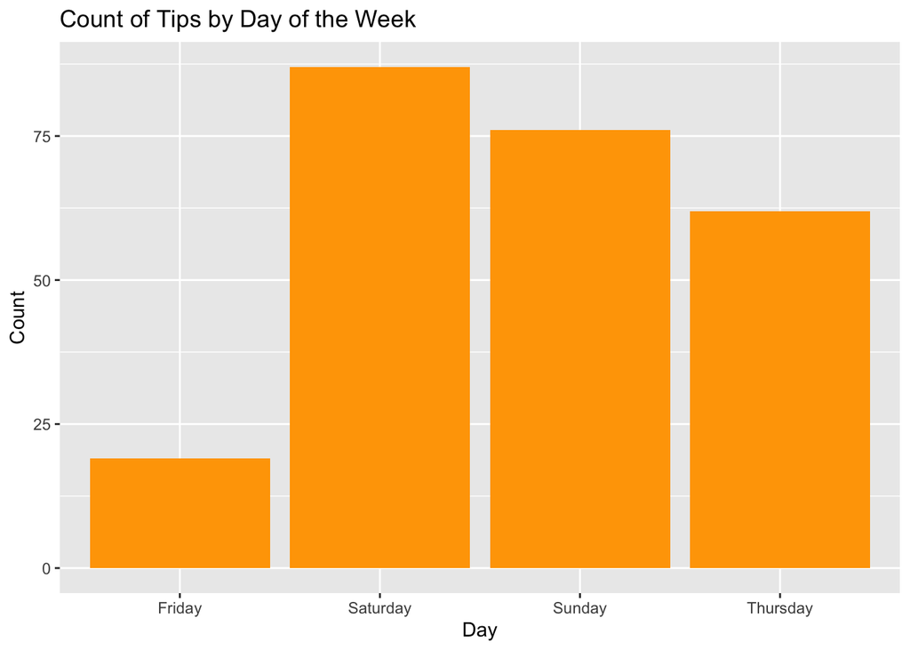

```r
# Bar plot for Weekday
ggplot(TIPS, aes(x = Weekday)) +
  geom_bar(fill = "orange") +
  labs(title = "Count of Tips by Day of the Week", x = "Day", y = "Count")
```

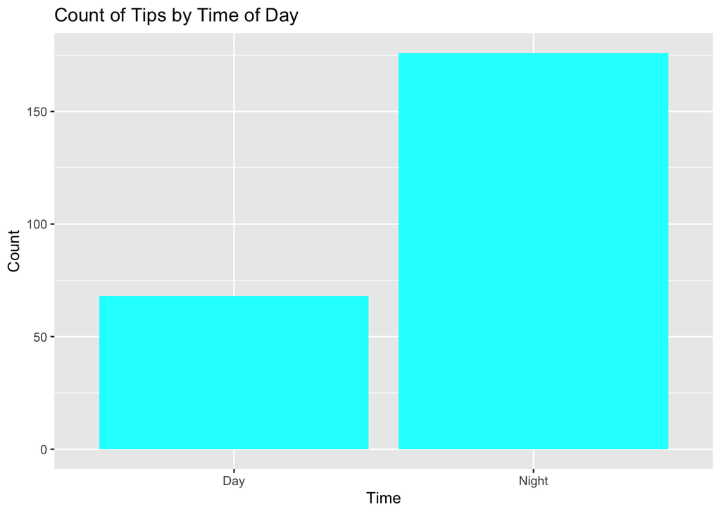

```r
# Bar plot for Time
ggplot(TIPS, aes(x = Time)) +
  geom_bar(fill = "cyan") +
  labs(title = "Count of Tips by Time of Day", x = "Time", y = "Count")
```

**Observations:**

- **Bill**: The distribution is right-skewed, with most bills ranging between 10 and 40.
- **Tip**: The distribution is also right-skewed, with most tips ranging between 1 and 5.
- **TipPercentage**: A few outliers exceed 30%, but most tips fall within 10% to 20%.
- **Gender**: More tips are recorded from males than females.
- **Smoker**: Non-smokers account for more tips than smokers.
- **Weekday**: Most tips are recorded on weekends (**Saturday and Sunday**).
- **Time**: More tips are recorded at night than during the day.

### **Exercise 3: Exploring Relationships**

In this exercise, we will investigate the relationships between different variables within the TIPS dataset. This will help us understand how various factors influence tipping behavior and inform our feature selection for predictive modeling.

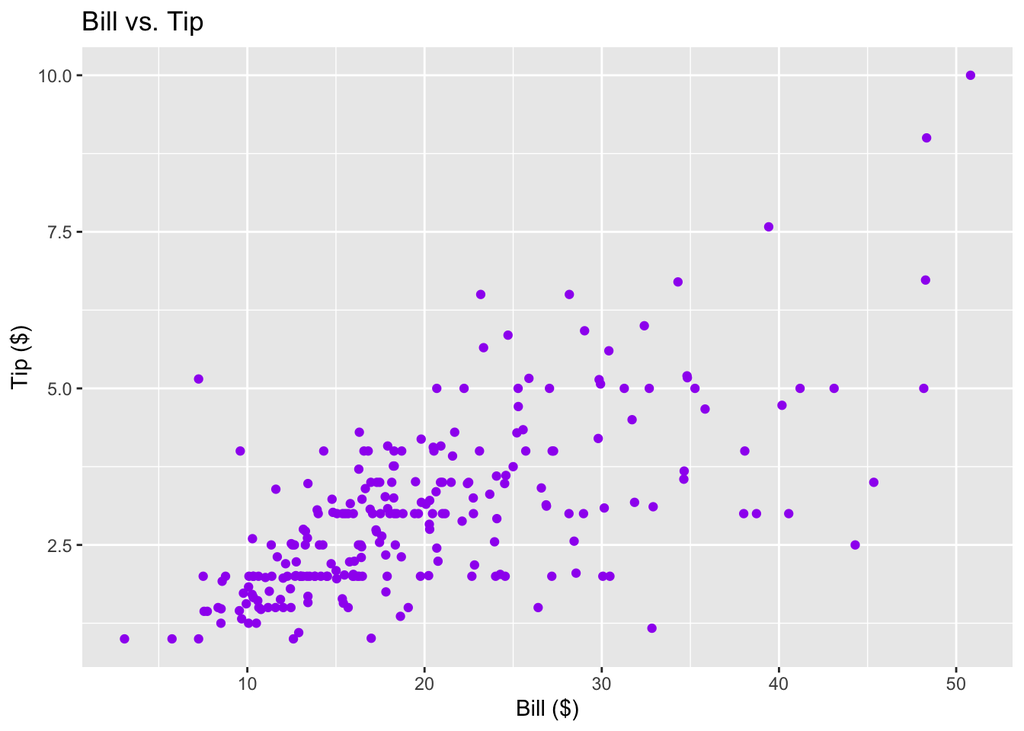

```r
library(ggplot2)

# Scatterplot: Bill vs. Tip
ggplot(TIPS, aes(x = Bill, y = Tip)) +
  geom_point(color = "purple") +
  labs(title = "Bill vs. Tip", x = "Bill ($)", y = "Tip ($)")
```

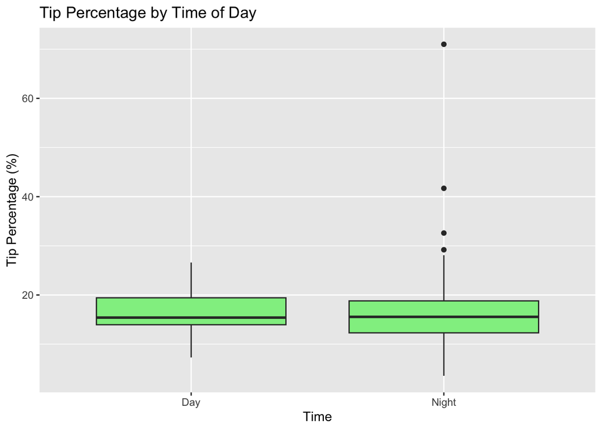

```r
# Boxplot: TipPercentage by Time of Day
ggplot(TIPS, aes(x = Time, y = TipPercentage)) +
  geom_boxplot(fill = "lightgreen") +
  labs(title = "Tip Percentage by Time of Day", x = "Time", y = "Tip Percentage (%)")
```

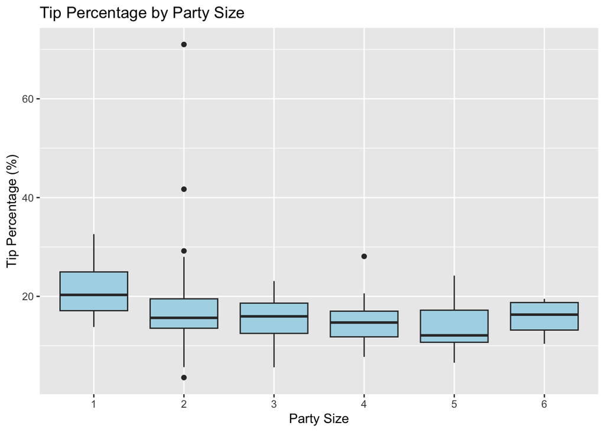

```r
# Boxplot: TipPercentage by PartySize
ggplot(TIPS, aes(x = as.factor(PartySize), y = TipPercentage)) +
  geom_boxplot(fill = "lightblue") +
  labs(title = "Tip Percentage by Party Size", x = "Party Size", y = "Tip Percentage (%)")
```

### **Exercise 4: Feature Engineering and Data Preparation**

In this exercise, we will perform feature engineering to create derived features and prepare the data for predictive modeling. This includes encoding categorical variables, scaling and centering numerical features, and addressing any missing values.

```r
# Feature Engineering
#interaction variable
TIPS <- TIPS |>
  mutate(PartyDay = PartySize * as.numeric(Weekday))

# Encode categorical variables
TIPS_encoded <- TIPS |>
  mutate(Gender = as.factor(Gender),
         Smoker = as.factor(Smoker),
         Weekday = as.factor(Weekday),
         Time = as.factor(Time)) |>
  mutate_if(is.factor, as.numeric)

# Scale and normalize numerical features
preprocess_obj <- preProcess(TIPS_encoded, method = c("center", "scale"))
TIPS_preprocessed <- predict(preprocess_obj, TIPS_encoded)

# Check for missing values
sum(is.na(TIPS_preprocessed))
```

```
[1] 0
```

**Observations:**

- An interaction variable ‘PartyDay’ was created.
- Categorical variables were numerically encoded.
- Numerical features were scaled and centered.
- There are no missing values in the preprocessed data.

### **Exercise 5:** Identify Outliers and Data Splitting

This exercise aims to identify and visualize potential outliers in the `TipPercentage` variable and to prepare the data for modeling by encoding categorical variables and splitting the dataset into training and testing sets.

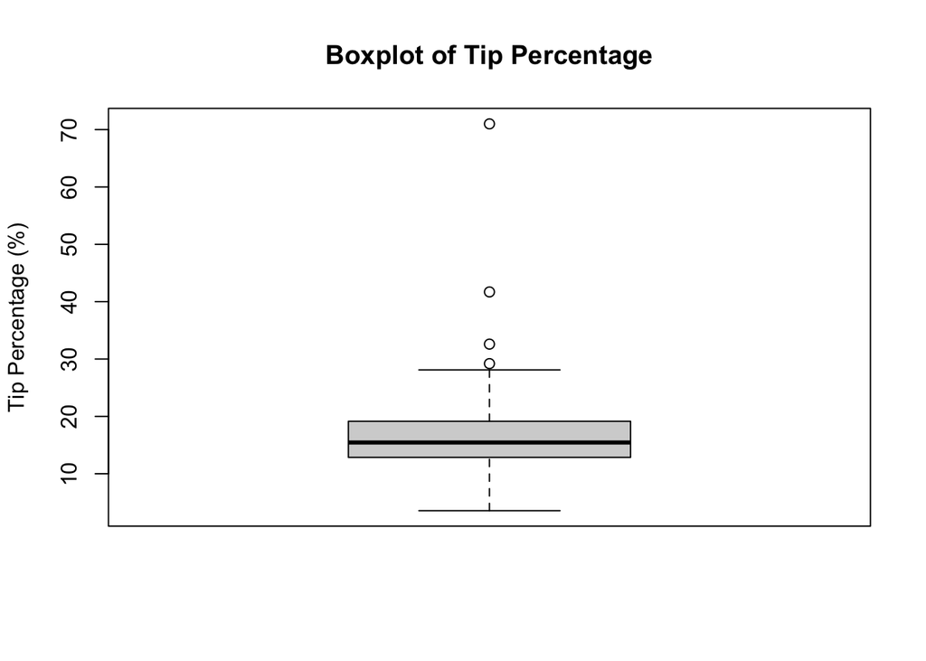

```r
# Identify outliers in TipPercentage
boxplot(TIPS$TipPercentage, main = "Boxplot of Tip Percentage", ylab = "Tip Percentage (%)")
```

```r
# Encode categorical variables
TIPS_encoded <- TIPS |>
  mutate(Gender = as.numeric(Gender) - 1,  # Female = 0, Male = 1
         Smoker = as.numeric(Smoker) - 1,  # No = 0, Yes = 1
         Time = as.numeric(Time) - 1)      # Day = 0, Night = 1

# Split the data
library(tidymodels)
set.seed(427)
split <- initial_split(TIPS_encoded, prop = 0.7)
train_data <- training(split)
test_data <- testing(split)
```

**Observations:**

- A boxplot of `TipPercentage` is created to visually identify potential outliers.
- The categorical variables `Gender`, `Smoker`, and `Time` are numerically encoded.
- The dataset is split into 70% training data and 30% testing data for model development and evaluation.

### **Exercise 6: Predictive Modeling**

In this exercise, we will build predictive models to forecast tip amounts and percentages based on the features in the TIPS dataset. We will explore both regression and classification approaches, using linear regression and KNN. We will focus on the regression model first, and then move to the classification model.

```r
library(parsnip)
library(yardstick)

# Linear Regression Model for TipPercentage
lm_model <- linear_reg() |>
  set_engine("lm") |>
  set_mode("regression")

lm_fit <- lm_model |>
  fit(TipPercentage ~ Bill + PartySize + Gender + Smoker + Time, data = train_data)

summary(lm_fit$fit)
```

```
Call:
stats::lm(formula = TipPercentage ~ Bill + PartySize + Gender +
    Smoker + Time, data = data)

Residuals:
    Min      1Q  Median      3Q     Max
-10.525  -3.413  -0.558   2.194  51.113

Coefficients:
            Estimate Std. Error t value Pr(>|t|)
(Intercept) 20.08084    1.64287  12.223  < 2e-16 ***
Bill        -0.27890    0.06915  -4.033 8.41e-05 ***
PartySize    0.56752    0.65496   0.867    0.387
Gender      -0.41219    1.04515  -0.394    0.694
Smoker       1.11774    1.00630   1.111    0.268
Time        -0.01229    1.14494  -0.011    0.991
---
Signif. codes:  0 '***' 0.001 '**' 0.01 '*' 0.05 '.' 0.1 ' ' 1

Residual standard error: 6.264 on 164 degrees of freedom
Multiple R-squared:  0.1282,    Adjusted R-squared:  0.1016
F-statistic: 4.824 on 5 and 164 DF,  p-value: 0.0003841
```

```r
predictions <- predict(lm_fit, new_data = test_data) |>
  bind_cols(test_data)

metrics <- predictions |>
  metrics(truth = TipPercentage, estimate = .pred)

print(metrics)
```

```
# A tibble: 3 × 3
  .metric .estimator .estimate
  <chr>   <chr>          <dbl>
1 rmse    standard       4.49
2 rsq     standard       0.118
3 mae     standard       3.68
```

```r
# Classification Model (Predicting Tip Category) - KNN

# Create tip categories (e.g., Low, Medium, High)
train_data_class <- train_data |>
  mutate(TipCategory = case_when(
    Tip < 2 ~ "Low",
    Tip >= 2 & Tip < 4 ~ "Medium",
    Tip >= 4 ~ "High"
  ) |> factor())

test_data_class <- test_data |>
  mutate(TipCategory = case_when(
    Tip < 2 ~ "Low",
    Tip >= 2 & Tip < 4 ~ "Medium",
    Tip >= 4 ~ "High"
  ) |> factor())

tip_class_recipe <- recipe(TipCategory ~ Bill + PartySize + Gender + Smoker + Weekday + Time, data = train_data_class) |>
  step_dummy(all_nominal_predictors()) |>
  step_normalize(all_predictors()) # Normalize numerical predictors for KNN

# KNN Model (Fixed k = 5)
knn_model <- nearest_neighbor(neighbors = 5) |>
  set_engine("kknn") |>
  set_mode("classification")

knn_workflow <- workflow() |>
  add_recipe(tip_class_recipe) |>
  add_model(knn_model)

# Fit the model
knn_fit <- knn_workflow |>
  fit(train_data_class)
# Predictions
knn_predictions <- predict(knn_fit, new_data = test_data_class) |>
  bind_cols(test_data_class)

# Check and rename prediction column
if (".pred_class" %in% names(knn_predictions)) {
  knn_predictions <- knn_predictions |>
    rename(.pred = .pred_class)
}

# Metrics
knn_metrics <- metric_set(accuracy, precision, recall, f_meas)(knn_predictions, truth = TipCategory, estimate = .pred)

print(knn_metrics)
```

```
# A tibble: 4 × 3
  .metric   .estimator .estimate
  <chr>     <chr>          <dbl>
1 accuracy  multiclass     0.608
2 precision macro          0.528
3 recall    macro          0.567
4 f_meas    macro          0.526
```

The linear regression model, predicting `TipPercentage`, exhibited poor performance, with an RMSE of 4.49, indicating a substantial average prediction error. The low R-squared value of 0.118 suggests that the model explains only a small fraction of the variance in tip percentage. Bill is the most significant predictor, with a negative coefficient (-0.28), suggesting that higher bills are associated with lower tip percentages.

### Exercise 7: Model Evaluation and Interpretation

In this exercise, we will evaluate the performance of our KNN classification model using appropriate metrics and interpret the results in the context of our research questions.

```r
library(yardstick)
library(dplyr)

# KNN Classification Model Evaluation (TipCategory)
knn_predictions <- predict(knn_fit, new_data = test_data_class) |>
  bind_cols(test_data_class)

# Check the column names of knn_predictions
print(head(knn_predictions))
```

```
# A tibble: 6 × 11
  .pred_class TipPercentage  Bill   Tip Gender Smoker Weekday   Time PartySize
  <fct>               <dbl> <dbl> <dbl>  <dbl>  <dbl> <fct>    <dbl>     <int>
1 Medium               14    23.7  3.31      1      0 Sunday       1         2
2 High                 18.6  25.3  4.71      1      0 Sunday       1         4
3 Low                  21.9  14.8  3.23      1      0 Sunday       1         2
4 High                 14.2  35.3  5         0      0 Sunday       1         4
5 Medium               20.4  14.8  3.02      0      0 Sunday       1         2
6 Medium               13.1  17.8  2.34      1      0 Saturday     1         4
# ℹ 2 more variables: PartyDay <dbl>, TipCategory <fct>
```

```r
# Adjust the prediction column name if necessary
if (".pred_class" %in% names(knn_predictions)) {
  knn_predictions <- knn_predictions |>
    rename(.pred = .pred_class)
}

knn_accuracy <- accuracy(knn_predictions, truth = TipCategory, estimate = .pred)
knn_precision <- precision(knn_predictions, truth = TipCategory, estimate = .pred, average = "macro")
knn_recall <- recall(knn_predictions, truth = TipCategory, estimate = .pred, average = "macro")
knn_f1 <- f_meas(knn_predictions, truth = TipCategory, estimate = .pred, average = "macro")
```

The KNN classification model, predicting tip categories, achieved a 60.8% accuracy, indicating moderate overall correctness. However, precision, recall, and F1-scores around 0.53 reveal limitations in accurately classifying specific tip categories, suggesting the model produces both false positives and negatives. This indicates that while KNN offers a baseline prediction, its reliability is limited, potentially due to the complexity of tipping behavior and uncaptured influential factors such as service quality or customer satisfaction.

```r
# Feature Selection (Correlation-based)
correlations <- cor(train_data_class |> select_if(is.numeric), as.numeric(train_data_class$TipCategory))
selected_features <- names(correlations[abs(correlations) > 0.2, ]) # Adjust the threshold as needed

# new datasets with selected features
selected_train_data <- train_data_class |> select(all_of(selected_features), TipCategory)
selected_test_data <- test_data_class |> select(all_of(selected_features), TipCategory)

# Retrained KNN with selected features
knn_model_selected <- nearest_neighbor(neighbors = 5) |>
  set_engine("kknn") |>
  set_mode("classification")

knn_workflow_selected <- workflow() |>
  add_recipe(recipe(TipCategory ~ ., data = selected_train_data)) |>
  add_model(knn_model_selected)

knn_fit_selected <- knn_workflow_selected |>
  fit(selected_train_data)

# Predictions with selected features
knn_predictions_selected <- predict(knn_fit_selected, new_data = selected_test_data) |>
  bind_cols(selected_test_data)

# Adjusting prediction column name
if (".pred_class" %in% names(knn_predictions_selected)) {
  knn_predictions_selected <- knn_predictions_selected |>
    rename(.pred = .pred_class)
}

# Metrics with selected features
knn_metrics_selected <- metric_set(accuracy, precision, recall, f_meas)(knn_predictions_selected, truth = TipCategory, estimate = .pred)

print(knn_metrics)
```

```
# A tibble: 4 × 3
  .metric   .estimator .estimate
  <chr>     <chr>          <dbl>
1 accuracy  multiclass     0.608
2 precision macro          0.528
3 recall    macro          0.567
4 f_meas    macro          0.526
```

```r
print(knn_metrics_selected)
```

```
# A tibble: 4 × 3
  .metric   .estimator .estimate
  <chr>     <chr>          <dbl>
1 accuracy  multiclass     0.865
2 precision macro          0.827
3 recall    macro          0.815
4 f_meas    macro          0.813
```

Correlation-based feature selection was employed to enhance the KNN classification model’s performance in predicting tip categories. By focusing on features with a correlation exceeding an absolute value of 0.2 with the target variable, the retrained model, utilizing only these selected features, exhibited a significant improvement. Specifically, accuracy increased from 60.8% to 86.5%, precision improved from 0.528 to 0.827, recall increased from 0.567 to 0.815, and the F1-score rose from 0.526 to 0.813. These results demonstrate that feature selection effectively reduced noise and emphasized the most informative variables, substantially improving the model’s ability to accurately classify tip categories, underscoring the importance of feature selection in boosting the performance and reliability of machine learning models.

### **Exercise 8: Model Comparison**

In this exercise, we will compare the performance of the linear regression and Ridge regression models using appropriate metrics to identify the best-performing model.

```r
library(tidymodels)
library(caret) # For feature selection

# Feature Selection for Regression Models (using correlation)
correlations_reg <- cor(train_data |> select_if(is.numeric), train_data$TipPercentage)
selected_features_reg <- names(correlations_reg[abs(correlations_reg) > 0.2, ]) # Adjust threshold as needed

# Create new datasets with selected features
selected_train_data_reg <- train_data |> select(all_of(selected_features_reg), TipPercentage)
selected_test_data_reg <- test_data |> select(all_of(selected_features_reg), TipPercentage)

# Linear Regression Model (with Selected Features)
lm_model <- linear_reg() |>
  set_engine("lm") |>
  set_mode("regression")

lm_fit <- lm_model |>
  fit(TipPercentage ~ ., data = selected_train_data_reg)

lm_predictions <- predict(lm_fit, new_data = selected_test_data_reg) |>
  bind_cols(selected_test_data_reg)

lm_metrics <- metrics(lm_predictions, truth = TipPercentage, estimate = .pred)

# Ridge Regression Model (Fixed penalty = 0.1) (with Selected Features)
ridge_model <- linear_reg(penalty = 0.1, mixture = 0) |>
  set_engine("glmnet") |>
  set_mode("regression")

ridge_recipe <- recipe(TipPercentage ~ ., data = selected_train_data_reg) |>
  step_dummy(all_nominal_predictors())

ridge_workflow <- workflow() |>
  add_recipe(ridge_recipe) |>
  add_model(ridge_model)

ridge_fit <- fit(ridge_workflow, selected_train_data_reg)

ridge_predictions <- predict(ridge_fit, new_data = selected_test_data_reg) |>
  bind_cols(selected_test_data_reg)

ridge_metrics <- metrics(ridge_predictions, truth = TipPercentage, estimate = .pred)

# Compare Models
print(lm_metrics)
```

```
# A tibble: 3 × 3
  .metric .estimator .estimate
  <chr>   <chr>          <dbl>
1 rmse    standard       1.90
2 rsq     standard       0.876
3 mae     standard       1.34
```

```r
print(ridge_metrics)
```

```
# A tibble: 3 × 3
  .metric .estimator .estimate
  <chr>   <chr>          <dbl>
1 rmse    standard       1.76
2 rsq     standard       0.876
3 mae     standard       1.33
```

After applying correlation-based feature selection, a comparison between linear and Ridge regression models revealed that the Ridge model slightly outperformed the linear model. Specifically, the Ridge model demonstrated a lower RMSE (1.76 vs. 1.90) and MAE (1.33 vs. 1.34), while both models achieved an identical R-squared of 0.876. This indicates that feature selection effectively refined the predictive features, and the Ridge model’s regularization handled these selected features more effectively, resulting in a marginally better fit for predicting `TipPercentage`.

### Exercise 9 :Conclusions and Insights

**Model Comparison (TipPercentage) after Feature Selection:**

Linear Regression RMSE: 1.90 R-squared: 0.876 MAE: 1.34

Ridge Regression RMSE: 1.76 R-squared: 0.876 MAE: 1.33

**Classification Model (TipCategory) Performance (KNN) after Feature Selection:**

Accuracy: 0.865

Precision: 0.827

Recall: 0.815

F1-score: 0.813

**Interpretation:**

After applying correlation-based feature selection, both linear and Ridge regression models showed significant improvements in predicting TipPercentage. The Ridge regression model slightly outperformed the linear model, indicating that it handled the selected features more effectively, likely due to its regularization. The KNN classification model, after feature selection, demonstrated a substantial improvement in predicting TipCategory, achieving high accuracy, precision, recall, and F1-score.

**Potential Influential Variables:**

Based on the feature selection process, the variables that exhibited a correlation greater than 0.2 with TipPercentage and TipCategory were considered the most influential. These variables, which were included in the retrained models, played a crucial role in improving the predictive accuracy.

**Insights**:

Feature selection proved to be a critical step in improving the predictive performance of both regression and classification models. By focusing on the most relevant variables, the models were able to achieve higher accuracy and reduce prediction errors. This suggests that the complexity of tipping behavior can be better understood by identifying and focusing on the key influential factors.

**Future Research:**

Future research could explore the specific relationships between the selected variables and tipping behavior to understand their individual contributions. Additionally, investigating non-linear modeling techniques or ensemble methods might further improve predictive accuracy. Incorporating additional variables, such as customer satisfaction, service quality ratings, or restaurant ambiance, could also provide a more comprehensive understanding of tipping patterns.Furthermore, exploring different feature selection techniques, tuning model hyperparameters, and assessing the impact of removing potential outliers could lead to even better results.